# Montag children’s book corpus

gender analysis

Molly Lewis

2018-03-09

### Montag corpus

```r
d_raw <- read_lines("100Books.txt")  %>%
  as.data.frame() %>%
  rename("text" = ".")

book_titles <- d_raw %>%
  filter(str_detect(text, regex("^Title", ignore_case = TRUE))) %>%
  rename(title = text) %>%
  mutate(book_id = 1:n(),
         title = str_replace(title, "Title: ", "")) %>%
  select(book_id, title)

author_names <- d_raw %>%
  filter(str_detect(text, regex("^Author", ignore_case = TRUE))) %>%
  rename(author = text) %>%
  mutate(book_id = 1:n(),
         author = str_replace(author, "Author: ", "")) %>%
  select(book_id, author)

d_clean <- d_raw %>%
    mutate(book_id = cumsum(str_detect(text, regex("^Title",
                                                 ignore_case = TRUE)))) %>%
    left_join(book_titles) %>%
    left_join(author_names) %>%
    filter(!str_detect(text, regex("^Title",
                                                 ignore_case = TRUE)),
           !str_detect(text, regex("^Author",
                                                 ignore_case = TRUE)),
           text != "") %>%
    group_by(book_id) %>%
    mutate(line_number = row_number(),
           text = as.character(text)) %>%
    ungroup() %>%
    select(book_id, title, author, line_number, text)

tidy_books <- d_clean %>%
  unnest_tokens(word, text) #%>%
  #anti_join(stop_words)
```

### Glasglow norms

(Gender + others)

Overall distribution of words in Glasglow dataset:

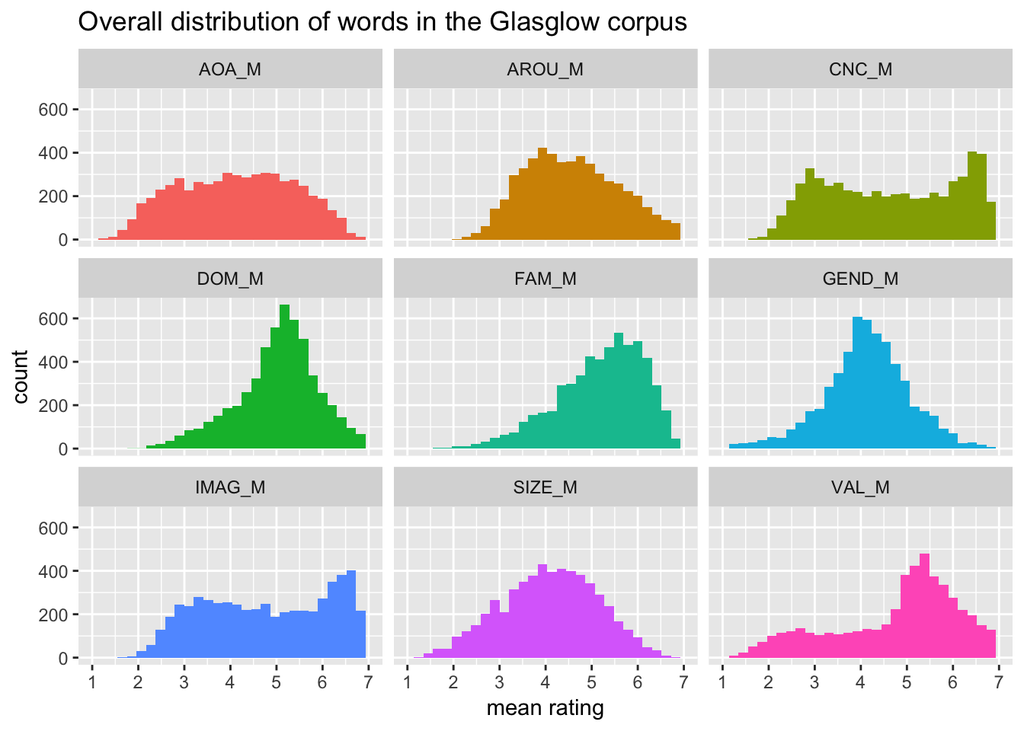

```r
norms <- read_csv("GlasgowNorms.csv") %>%
  select(word, GEND_M, contains("_M"))

norms %>%
  gather("norm", "rating", -1) %>%
  ggplot(aes(x = rating, fill = norm)) +
    ggtitle("Overall distribution of words in the Glasglow corpus")+
    geom_histogram() +
    facet_wrap(~norm) +
    scale_x_continuous(name="mean rating",
                     limits=c(1, 7),
                     breaks=1:7) +
    theme(legend.position = "none")
```

```r
overall_means <- norms %>%
  gather("norm", "rating", -1) %>%
  group_by(norm) %>%
  summarize(mean_rating = mean(rating))
```

```r
tidy_with_norms <- tidy_books %>%
  left_join(norms)

prop_na_type <- tidy_with_norms %>%
  distinct(word, .keep_all = T) %>%
  summarize(prop_na = length(which(is.na(AROU_M)))/n())


prop_na_token <- tidy_with_norms %>%
  summarize(prop_na = length(which(is.na(AROU_M)))/n())
```

### Mean ratings by book

They’re sorted here from most feminine to most masculine.

```r
norm_means <- tidy_with_norms %>%
  filter(!is.na(AROU_M)) %>%
  gather("norm", "value", -1:-5) %>%
  group_by(title, norm) %>%
  multi_boot_standard(col = "value")

norm_means_wide <- norm_means %>%
  select(norm, mean) %>%
  spread(norm, mean)  %>%
  select(title, GEND_M, everything()) %>%
  arrange(GEND_M)

kable(norm_means_wide, "html") %>%
  kable_styling() %>%
  scroll_box(width = "900px", height = "400px")
```

| title | GEND_M | AOA_M | AROU_M | CNC_M | DOM_M | FAM_M | IMAG_M | SIZE_M | VAL_M |
| --- | --- | --- | --- | --- | --- | --- | --- | --- | --- |
| Are You My Mother? | 3.086102 | 1.950060 | 4.679632 | 5.700029 | 5.293174 | 6.288131 | 5.930034 | 3.740749 | 6.373692 |
| I’m a Big Sister | 3.204762 | 2.073509 | 4.959014 | 4.897186 | 5.208189 | 6.303503 | 5.112623 | 3.698327 | 6.329876 |
| The Napping House | 3.216098 | 1.984250 | 4.413992 | 6.511882 | 5.168945 | 6.321110 | 6.634562 | 3.314182 | 6.235493 |
| The Keeping Quilt | 3.363114 | 2.427299 | 5.070592 | 5.040075 | 5.368388 | 6.217781 | 5.345046 | 4.294733 | 6.372930 |
| Goodnight Moon | 3.379662 | 2.188090 | 4.420762 | 5.326356 | 5.149723 | 6.180664 | 5.574990 | 3.582374 | 5.735695 |
| Froggy Goes to Bed | 3.418877 | 2.045057 | 4.757741 | 4.909668 | 5.408733 | 6.394247 | 5.273269 | 4.168571 | 6.246195 |
| Olivia | 3.447625 | 2.172478 | 4.860050 | 4.392803 | 5.314612 | 6.419290 | 4.759819 | 4.520293 | 6.412796 |
| The Very Hungry Caterpillar | 3.462584 | 2.188300 | 4.642197 | 5.603079 | 5.264290 | 6.226718 | 5.947966 | 3.063184 | 5.968813 |
| The Gardener | 3.467804 | 2.392910 | 4.810750 | 4.324236 | 5.322233 | 6.189349 | 4.591375 | 4.404159 | 6.348240 |
| That Is Not a Good Idea! | 3.491074 | 2.587442 | 5.376668 | 3.921826 | 5.794505 | 6.229516 | 4.424508 | 4.461318 | 6.815955 |
| Chrysanthemum | 3.495166 | 2.299549 | 4.797559 | 4.565621 | 5.305383 | 6.271452 | 4.700129 | 4.167527 | 6.148181 |
| Blueberries for Sal | 3.536909 | 2.225843 | 4.431099 | 4.617415 | 5.063399 | 6.174434 | 4.893417 | 3.875205 | 5.637217 |
| Guess How Much I Love You | 3.552337 | 2.079446 | 5.089135 | 4.086194 | 5.360925 | 6.448068 | 4.776981 | 4.345090 | 6.199294 |
| Madeline | 3.574783 | 2.222619 | 4.907449 | 4.970347 | 5.113866 | 6.290250 | 5.413071 | 4.130875 | 5.771443 |
| Bunny Party | 3.579498 | 2.433840 | 4.534957 | 5.278561 | 5.195033 | 6.003423 | 5.583038 | 3.590238 | 5.661360 |
| Goldilicious | 3.591044 | 2.538230 | 5.141014 | 4.408096 | 5.411224 | 5.971311 | 4.808480 | 4.230467 | 6.114151 |
| The Other Side | 3.607645 | 2.358981 | 4.806698 | 4.681328 | 5.326398 | 6.130927 | 5.031507 | 4.280158 | 5.975970 |
| Miss Rumphius | 3.635078 | 2.373868 | 4.923219 | 4.694589 | 5.415985 | 6.204462 | 5.090181 | 4.482335 | 6.128586 |
| The Little House | 3.641425 | 2.319916 | 4.743115 | 4.817982 | 5.266073 | 6.335096 | 5.195645 | 4.288129 | 5.855164 |
| Llama Llama Red Pajama | 3.648757 | 2.876766 | 4.474624 | 5.590108 | 5.196401 | 5.488909 | 5.893359 | 3.793070 | 5.798533 |
| The Runaway Bunny | 3.652868 | 2.399355 | 4.655759 | 4.875620 | 5.354397 | 6.054384 | 4.984472 | 3.864742 | 5.939684 |
| No, David! | 3.660354 | 2.304991 | 5.054600 | 4.210282 | 5.306427 | 6.243909 | 4.391664 | 4.027409 | 5.973736 |
| Maisy Goes to the Library | 3.661156 | 2.175672 | 4.813185 | 5.308303 | 5.605944 | 6.361321 | 5.479302 | 3.742457 | 6.195298 |
| Bread and Jam for Frances | 3.665128 | 2.219585 | 4.450208 | 5.130079 | 5.285811 | 6.279618 | 5.351416 | 3.521484 | 5.932542 |
| A Bad Case of Stripes | 3.669853 | 2.638101 | 4.673780 | 4.420837 | 5.150991 | 6.174781 | 4.641232 | 4.143697 | 5.606783 |
| Lilly’s Purple Plastic Purse | 3.673390 | 2.471912 | 4.844748 | 4.444977 | 5.282346 | 6.235251 | 4.745907 | 4.207649 | 5.879621 |
| George and Martha | 3.677392 | 2.416316 | 4.688100 | 4.554739 | 5.461836 | 6.141413 | 4.768990 | 3.819544 | 5.846732 |
| Winter Days in the Big Woods | 3.682623 | 2.334184 | 4.533994 | 4.754417 | 5.308396 | 6.222308 | 5.022301 | 3.910773 | 5.699534 |
| Love You Forever | 3.683571 | 1.991328 | 4.961755 | 4.750582 | 5.352974 | 6.429034 | 5.181206 | 4.419031 | 6.255188 |
| The Day the Crayons Quit | 3.690086 | 2.302301 | 4.698286 | 4.481637 | 5.264238 | 6.201144 | 4.790584 | 3.992135 | 5.802656 |

[output cut: 70 more lines]

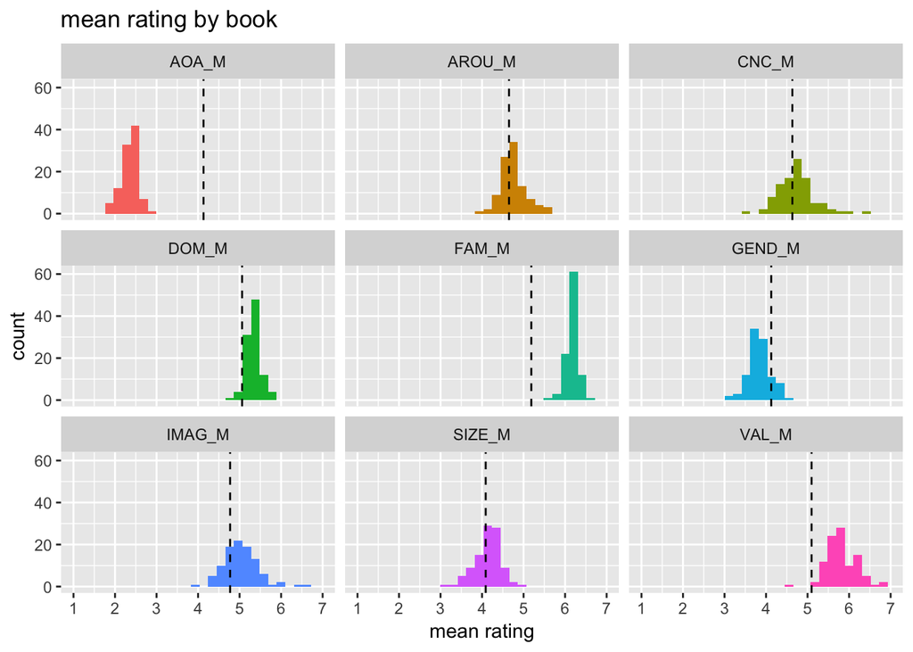

```r
norm_means %>%
  left_join(overall_means) %>%
  group_by(norm) %>%
    ggplot(aes(x = mean, fill = norm)) +
    geom_histogram() +
    facet_wrap(~norm) +
    ggtitle("mean rating by book") +
    geom_vline(aes(xintercept = mean_rating), linetype = 2) +
    scale_x_continuous(name = "mean rating",
                     limits = c(1, 7),
                     breaks = 1:7) +
    theme(legend.position = "none")
```

SCALE LABELS: (left to right)

- Arousal: Very Unarousing, Very Arousing
- Valence: Very Negative, Neutral, Very Positive
- Dominance: You are very Controlled, You are very Dominant
- Concreteness: Very Abstract, Very Concrete
- Imageability: Very Unimageable, Very Imageable
- AoA: 0-2, 3-4, 5-6, 7-8, 9-10, 11-12, 13+
- Semantic Size: Very Small, Very Big
- Gender association: Very Feminine, Very Masculine

Suprisingly, books are overall slightly more feminine than the overall sample of words. All the other norms look relatively sensible.

### Are the properties of books correlated?

Correlation matrix (color indicates signifance at the .05 level)

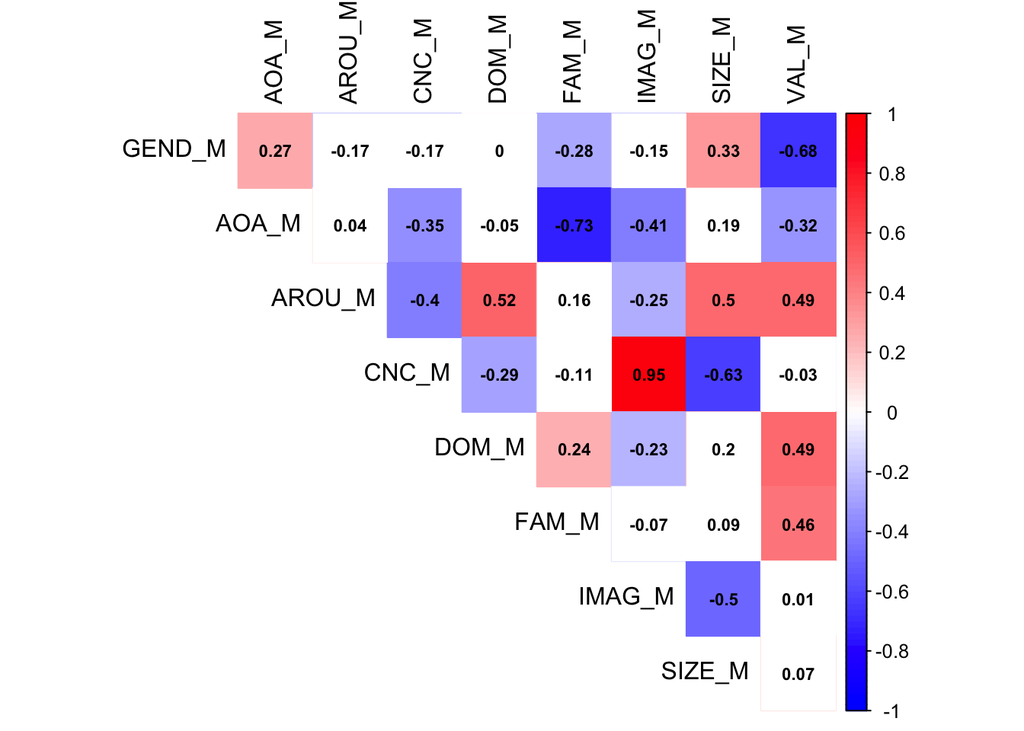

```r
corr_mat <- cor(norm_means_wide[,-1],
                use = "pairwise.complete.obs")

p.mat <- corrplot::cor.mtest(norm_means_wide[,-1],
                  use = "pairwise.complete.obs")$p

cols = rev(colorRampPalette(c("red", "white", "blue"))(100))

corrplot::corrplot(corr_mat, method = "color",  col = cols,
         type = "upper", order = "original", number.cex = .7,
         addCoef.col = "black",
         p.mat = p.mat, insig = "blank",
         tl.col = "black", tl.srt = 90,
         diag = FALSE)
```

A regression predicting the gender of the book with all other norms:

```r
lm(GEND_M ~ AOA_M+AROU_M+CNC_M+DOM_M+FAM_M +
     IMAG_M+ SIZE_M + VAL_M, d = norm_means_wide) %>%
  summary()
```

```
##
## Call:
## lm(formula = GEND_M ~ AOA_M + AROU_M + CNC_M + DOM_M + FAM_M +
##     IMAG_M + SIZE_M + VAL_M, data = norm_means_wide)
##
## Residuals:
##      Min       1Q   Median       3Q      Max
## -0.30409 -0.09799 -0.01589  0.09312  0.44614
##
## Coefficients:
##             Estimate Std. Error t value Pr(>|t|)
## (Intercept)  2.61380    1.60832   1.625   0.1076
## AOA_M       -0.02314    0.15214  -0.152   0.8795
## AROU_M      -0.15585    0.07452  -2.091   0.0393 *
## CNC_M        0.06403    0.15148   0.423   0.6735
## DOM_M        0.68539    0.10342   6.628 2.36e-09 ***
## FAM_M       -0.03220    0.18367  -0.175   0.8612
## IMAG_M       0.03197    0.14334   0.223   0.8240
## SIZE_M       0.41161    0.06796   6.057 3.08e-08 ***
## VAL_M       -0.62270    0.05664 -10.994  < 2e-16 ***
## ---
## Signif. codes:  0 '***' 0.001 '**' 0.01 '*' 0.05 '.' 0.1 ' ' 1
##
## Residual standard error: 0.1425 on 91 degrees of freedom
## Multiple R-squared:  0.7335, Adjusted R-squared:  0.7101
## F-statistic: 31.31 on 8 and 91 DF,  p-value: < 2.2e-16
```